# multidimens_tarabikin

I am using the tarabiking data to test the multidimensional data.

The data is grouped by age, and I excluded mice tested only once. We end up with 34 mice per group, genotype of the mice is unknown

```r
load("multidim.rdata")
summary (as.factor(metadata$treatment))
```

```
##  o  y
## 34 34
```

We grouped the variables following the MITsoft argument to get 10 behavior categories. We used the folowing time windows and got 10 x 5 = 50 variables :

```r
pander::pandoc.table(Timewindows)
```

| time_reference | windowstart | windowend |
| --- | --- | --- |
| Bin | 0 | 120 |
| Bintodark | -120 | 0 |
| Bintodark | 0 | 180 |
| Bintodark | 540 | 720 |
| Bintodark | 720 | 786 |

Note that the last window might be truncated if not all dataset is achieving 900 min after light on.

We then run a random forest to get the variables in order of importance to distinguish the groups.

```
## mtry = 7  OOB error = 20.59%
## Searching left ...
## mtry = 4     OOB error = 25%
## -0.2142857 0.05
## Searching right ...
## mtry = 14    OOB error = 20.59%
## 0 0.05
```

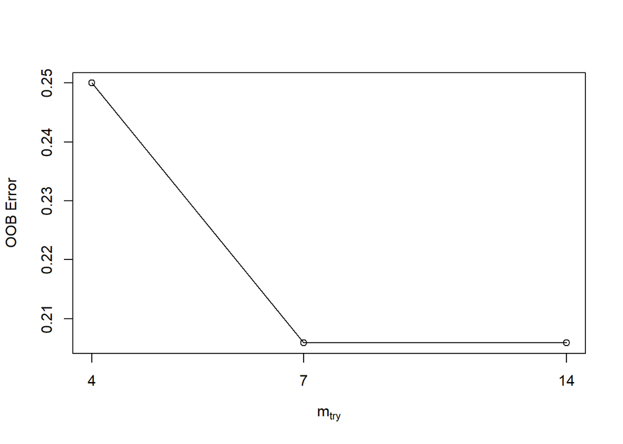

```
##        mtry  OOBError
## 4.OOB     4 0.2500000
## 7.OOB     7 0.2058824
## 14.OOB   14 0.2058824
```

```r
tuneRF(Multi_datainput_m%>% select (-groupingvar),Multi_datainput_m$groupingvar, ntreeTry=50, stepFactor=2, improve=0.05,
       trace=TRUE, plot=TRUE, doBest=FALSE)
```

```
## mtry = 7  OOB error = 25%
## Searching left ...
## mtry = 4     OOB error = 20.59%
## 0.1764706 0.05
## mtry = 2     OOB error = 26.47%
## -0.2857143 0.05
## Searching right ...
## mtry = 14    OOB error = 19.12%
## 0.07142857 0.05
## mtry = 28    OOB error = 20.59%
## -0.07692308 0.05
```

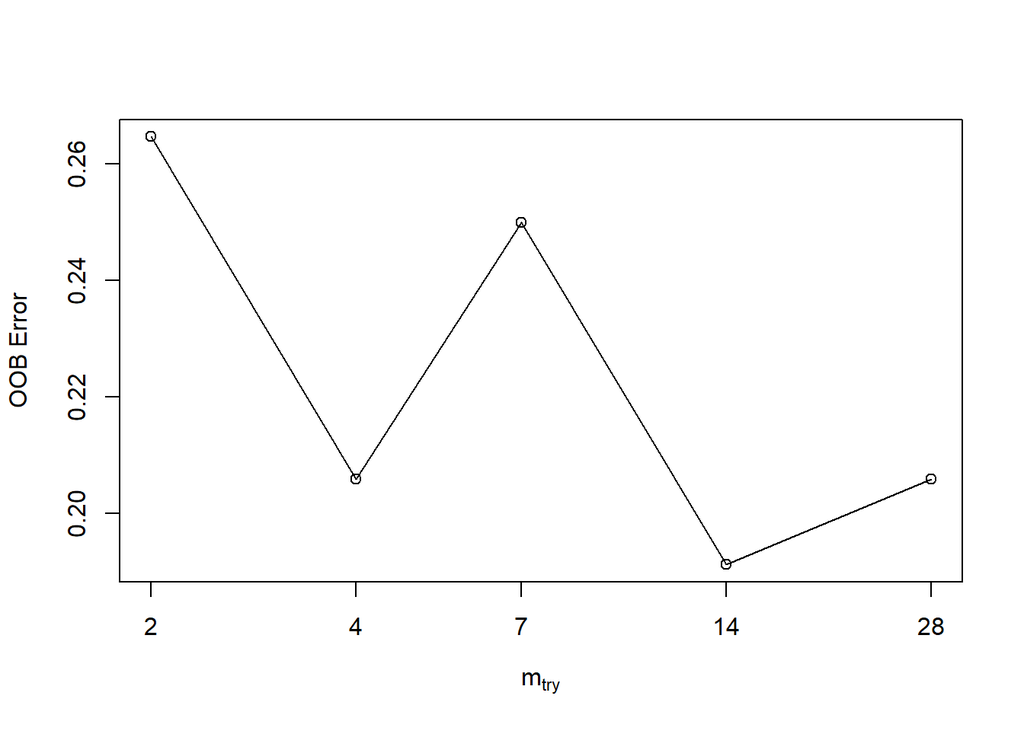

```
##        mtry  OOBError
## 2.OOB     2 0.2647059
## 4.OOB     4 0.2058824
## 7.OOB     7 0.2500000
## 14.OOB   14 0.1911765
## 28.OOB   28 0.2058824
```

```r
tuneRF(Multi_datainput_m%>% select (-groupingvar),Multi_datainput_m$groupingvar, ntreeTry=50, stepFactor=2, improve=0.05,
       trace=TRUE, plot=TRUE, doBest=FALSE)
```

We therefore used the random forest and plot here the table of variables ordered by weight:

```r
HCS.rf <- randomForest(groupingvar ~ ., data=Multi_datainput_m, importance=TRUE,
                        proximity=TRUE, mtry= 21, ntree =1500)

R =round(importance(HCS.rf, type=2), 2)
R2=data.frame(row.names (R),R)  %>% arrange(-MeanDecreaseGini)

pander::pandoc.table(R2)
```

```
##
## ---------------------------------------
##     row.names.R.      MeanDecreaseGini
## -------------------- ------------------
##        Hang5                4.28
##
##        Rear5                3.91
##
##  Unknown_behavior3          2.99
##
##        Hang4                2.89
##
##        Walk3                1.33
##
##         Eat5                1.19
##
##        Groom5               1.09
##
##        Hang3                1.07
##
##        Hang2                0.99
##
##     Micro_move5             0.83
##
##        Rear1                0.82
##
##        Groom3               0.74
##
##  Distance_traveled3         0.7
##
##  Unknown_behavior1          0.56
##
##  Unknown_behavior4          0.55
##
##        Groom2               0.53
##
##        Rear2                0.5
##
##        Drink2               0.5
##
```

[output cut: 49 more lines]

```
##
##     Micro_move2             0.15
##
##     Micro_move4             0.15
##
##        Drink4               0.15
##
##        Walk2                0.13
##
##         Eat2                0.09
##
##        Rest4                0.09
##
##        Drink3               0.06
## ---------------------------------------
```

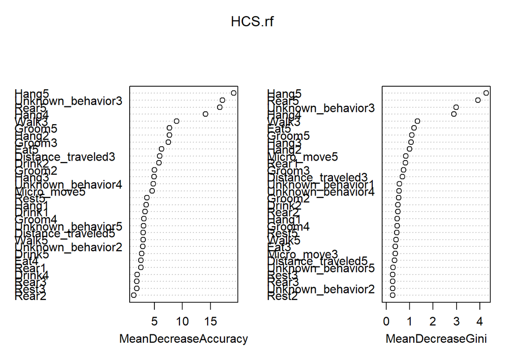

```r
varImpPlot(HCS.rf)
```

let’s try to get only the 20 first variables and run the random forest again:

```r
numberofvariables =20


Input =Multi_datainput_m [,names(Multi_datainput_m) %in% as.character(R2 [1:numberofvariables,1]) ]
Input$groupingvar =Multi_datainput_m$groupingvar

HCS.rf2 <- randomForest(groupingvar ~ ., data=Input, importance=TRUE,
                        proximity=TRUE, mtry= 21, ntree =1500)
```

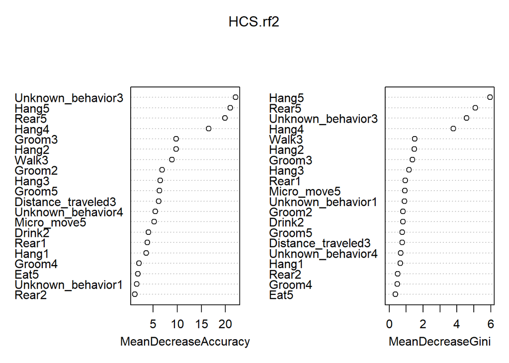

```r
varImpPlot(HCS.rf2)
```

Let’s take a teshold of of importance import_treshold and get all variables giving a MeanDecreaseGini over it (NB: THIS VARIABLE MIGHT NEED TO BE SET FOR EACH DATA):

```r
 import_treshold =0.95

R3=data.frame(row.names (R),R)  %>%
  filter(MeanDecreaseGini > import_treshold)
numberofvariables =nrow (R3)

Input =Multi_datainput_m [,names(Multi_datainput_m) %in% as.character(R2 [1:numberofvariables,1]) ]
Input$groupingvar =Multi_datainput_m$groupingvar

HCS.rf2 <- randomForest(groupingvar ~ ., data=Input, importance=TRUE,
                        proximity=TRUE, mtry= 21, ntree =1500)
```

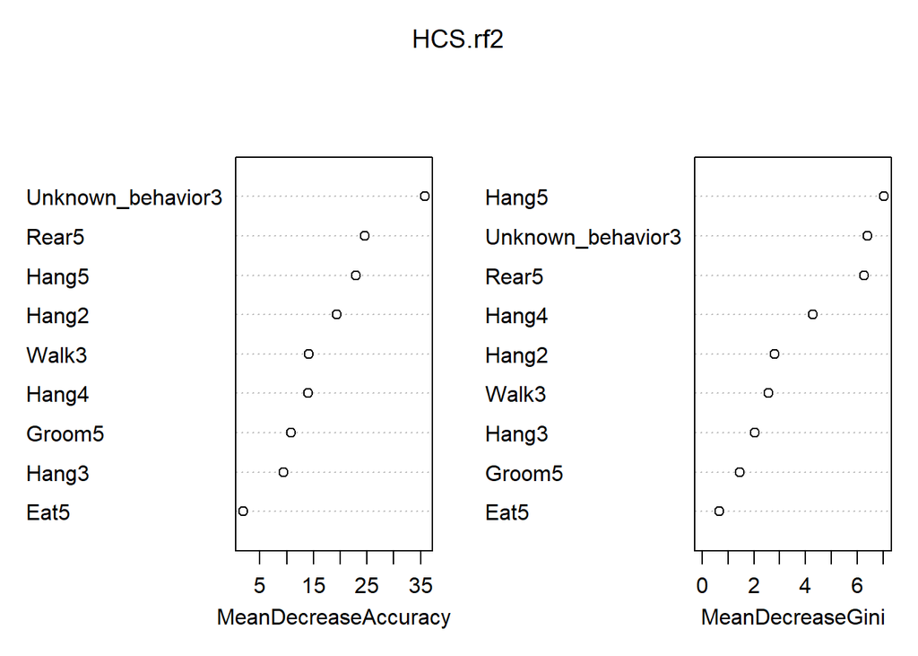

```r
varImpPlot(HCS.rf2)
```

# Plotting

Now is the time to plot the main components. For this, we will make an ICA on the reduced data and plot the first two components:

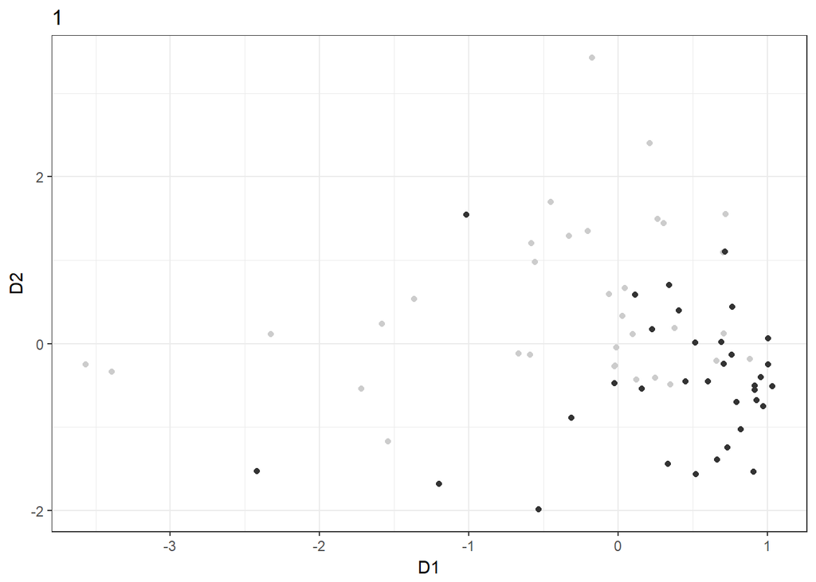

```r
 p=icafast(Input%>% select (-groupingvar),2,center=T,maxit=100)

R= cbind(p$Y, Input   %>% select (groupingvar))
    names(R) = c("D1", "D2",  "groupingvar")
    pls=R %>% ggplot (aes (x=D1, y=D2, color = groupingvar))+
      geom_point()+
      labs (title=nv)+
      scale_colour_grey() + theme_bw()+
      theme(legend.position='none')
print(pls)
```

# SVM

We perform a SVM on the total data or the reduced data and compare the results. For that with split the data in training and test sets, tune the svm for best parameters and then run the svm and gives the overall accuracy as the output. (the optimization of the parameters is computer intensive and may take time).

```r
##data input
Input =Multi_datainput_m [,names(Multi_datainput_m) %in% c(as.character(R2 [1:numberofvariables,1]), "groupingvar") ]

##data splitting
  L=levels(Input$groupingvar)
  Glass= Input %>% filter (groupingvar == L[1])
  Glass2= Input %>% filter (groupingvar == L[2])

  if (nrow (Glass) != nrow (Glass2)) stop("the groups do not have the same size !")

  index     <- 1:nrow(Glass )
  testindex <- sample(index, trunc(length(index)/3))
  testset   <- rbind(Glass[testindex,],Glass2[testindex,])
  trainset  <- rbind(Glass[-testindex,],Glass2[-testindex,])
##tuning and performing svm
  obj <- tune.svm(groupingvar~., data = trainset, gamma = 4^(-5:5), cost = 4^(-5:5),
                  tune.control(sampling = "cross"),kernel = "sigmoid")

  svm.model <- svm(groupingvar ~ ., data = trainset, cost = obj$best.parameters$cost, gamma = obj$best.parameters$gamma,kernel = "sigmoid")
  svm.pred <- predict(svm.model, testset %>% select(-groupingvar))

  SVMprediction_res =table(pred = svm.pred, true = testset$groupingvar)
  SVMprediction = as.data.frame(SVMprediction_res)

  #Accuracy of grouping and plot
  temp =classAgreement (SVMprediction_res)
  Accuracy =paste0(ncol(Input)-1," variables: Accuracy of the prediction (Corrected Rand index: 0 denotes chance level, maximum is 1):",temp$crand)

  print(Accuracy)
```

```
## [1] "9 variables: Accuracy of the prediction (Corrected Rand index: 0 denotes chance level, maximum is 1):0.26270136307311"
```

```r
#set.seed(71)
##data input)
Input =Multi_datainput_m
##data splitting
  L=levels(Input$groupingvar)
  Glass= Input %>% filter (groupingvar == L[1])
  Glass2= Input %>% filter (groupingvar == L[2])

  if (nrow (Glass) != nrow (Glass2)) stop("the groups do not have the same size !")

  index     <- 1:nrow(Glass )
  testindex <- sample(index, trunc(length(index)/3))
  testset   <- rbind(Glass[testindex,],Glass2[testindex,])
  trainset  <- rbind(Glass[-testindex,],Glass2[-testindex,])
##tuning and performing svm
  #obj <- tune.svm(groupingvar~., data = trainset, gamma = 4^(-5:5), cost = 4^(-5:5),tune.control(sampling = "cross"))

  svm.model <- svm(groupingvar ~ ., data = trainset, cost = obj$best.parameters$cost, gamma = obj$best.parameters$gamma,kernel = "sigmoid")
  svm.pred <- predict(svm.model, testset %>% select(-groupingvar),kernel = "sigmoid")

  SVMprediction_res =table(pred = svm.pred, true = testset$groupingvar)
  SVMprediction = as.data.frame(SVMprediction_res)

  #Accuracy of grouping and plot
  temp =classAgreement (SVMprediction_res)
  Accuracy =paste0(ncol(Input)-1," variables: Accuracy of the prediction (Corrected Rand index: 0 denotes chance level, maximum is 1):",temp$crand)

  print(Accuracy)
```

```
## [1] "50 variables: Accuracy of the prediction (Corrected Rand index: 0 denotes chance level, maximum is 1):0.379310344827586"
```

We will now use permutation to see if the computer can tell the two groups apart. What it does is permute the elements in random groups, calculate an accuracy score, then we will see if the accuracy we have is meaning that the two groups can actually be separated.